# Project 1: Wrangling, Exploration, Visualization

SDS322E

## Data Wrangling, Exploration, Visualization

### Jessica Chavarria, jc86585

#### Introduction

For this particular project, I wanted to do something that aligned with my personal interests and instantly thought of looking for data sets on anime shows. “Anime” defines a specific style of animated media (TV shows, movies, etc) originating from Japan. I’ve watched a variety of shows over the years since discovering anime in middle school, so I thought it would be neat to analyze descriptive information about them and see where the shows I love stand in terms of ratings or popularity. I ended up finding two data sets on Kaggle that would help me accomplish this. Both data sets include information from the MyAnimeList website, which is a social networking space for fans of anime to share their opinions on the shows they watch. Users add an anime they’ve seen to their personal list and give it a rating from 1-10, with scores closer to 10 reflecting a more positive opinion on the series. The ratings themselves don’t seem to have a universal Likert scale for evaluating, so the meaning of the rating depends primarily on the user themselves. This gives users the wiggle room to be as stringent as they want (or don’t want to be) with ratings.

The first data set, anime.csv, contains information about every anime title available on the website. The information includes each show’s MyAnimeList ID (“MAL_ID”), the official title, the average score across all user ratings (“Score”), genres, the show’s English and Japanese titles, type of medium (e.g. TV, movie, special), number of episodes, time frame in which it aired, the season the show premiered in, the producers, licencors and animation studios credited, the nature of the source material (e.g. original, manga/comic), content ratings, and more. The second dataset, animelist.csv, contains user-specific information where each user was assigned a random ID number (“user_id”). All the anime titles a user has in their list appear as separate observations (“anime_id”), along with the rating the user assigned to that particular title (“rating”), whether or not they’ve completed the whole series (“watching_status”), and the amount of episodes they’ve watched (“watched_episodes”). The watching status works according to this key:

1 = Currently watching 2 = Completed 3 = On-hold/paused 4 = Dropped 6 = Plan to watch

Below I read in both data sets and do a bit of wrangling in preparation for joining these data sets effectively.

```r
library(tidyverse)
library(kableExtra)
anime <- read_csv("datasets/anime.csv")
userlist <- read_csv("datasets/animelist.csv")
```

Due to the incredibly large amount of observations in the “userlist” data set (over 109,200,000+!), I had to cut down to the first 100,000 rows only for my code to run. The resulting data set was saved into a new object called “sample_userlist”, which allows me analyze about 309 total unique user IDs.

```r
##pulling first 100,000 rows of userlist to avoid RStudio crashing on me
sample_userlist <- userlist %>% slice(1:100000)
```

Lastly, before doing any tidying or joining, I wanted to clean up the anime data set a bit by keeping only the variables I was interested in analyzing and deleting the rest.

```r
##deleting variables/columns in anime.csv I'm not interested in
animetitles <- anime %>% select(c(MAL_ID, Name, Score, Genres, Type,
                                  Episodes, Premiered, Studios, Source,
                                  Rating, Ranked, Popularity, Members,
                                  Favorites, Watching, Completed, `On-Hold`,
                                  `Dropped`, `Plan to Watch`, `Score-10`,
                                  `Score-9`, `Score-8`, `Score-7`,
                                  `Score-6`, `Score-5`, `Score-4`,
                                  `Score-3`, `Score-2`, `Score-1`))
```

#### Tidying: Reshaping

```r
animetidy <- animetitles %>%
  pivot_longer(c("Score-10":"Score-1")) %>%
  separate(name, into=c("word","rating"), sep="-") %>%
  rename(global_nscore = value, global_meanscore = Score) %>%
  select(-word) %>%
  pivot_longer(c("Watching":"Plan to Watch")) %>%
  rename(global_watchstatus = name, global_nwatch = value)
glimpse(animetidy)
```

```
## Rows: 878,100
## Columns: 18
## $ MAL_ID             <dbl> 1, 1, 1, 1, 1, 1, 1, 1, 1, 1, 1, 1, 1, 1, 1, 1, 1, …
## $ Name               <chr> "Cowboy Bebop", "Cowboy Bebop", "Cowboy Bebop", "Co…
## $ global_meanscore   <chr> "8.78", "8.78", "8.78", "8.78", "8.78", "8.78", "8.…
## $ Genres             <chr> "Action, Adventure, Comedy, Drama, Sci-Fi, Space", …
## $ Type               <chr> "TV", "TV", "TV", "TV", "TV", "TV", "TV", "TV", "TV…
## $ Episodes           <chr> "26", "26", "26", "26", "26", "26", "26", "26", "26…
## $ Premiered          <chr> "Spring 1998", "Spring 1998", "Spring 1998", "Sprin…
## $ Studios            <chr> "Sunrise", "Sunrise", "Sunrise", "Sunrise", "Sunris…
## $ Source             <chr> "Original", "Original", "Original", "Original", "Or…
## $ Rating             <chr> "R - 17+ (violence & profanity)", "R - 17+ (violenc…
## $ Ranked             <chr> "28.0", "28.0", "28.0", "28.0", "28.0", "28.0", "28…
## $ Popularity         <dbl> 39, 39, 39, 39, 39, 39, 39, 39, 39, 39, 39, 39, 39,…
## $ Members            <dbl> 1251960, 1251960, 1251960, 1251960, 1251960, 125196…
## $ Favorites          <dbl> 61971, 61971, 61971, 61971, 61971, 61971, 61971, 61…
## $ rating             <chr> "10", "10", "10", "10", "10", "9", "9", "9", "9", "…
## $ global_nscore      <chr> "229170.0", "229170.0", "229170.0", "229170.0", "22…
## $ global_watchstatus <chr> "Watching", "Completed", "On-Hold", "Dropped", "Pla…
## $ global_nwatch      <dbl> 105808, 718161, 71513, 26678, 329800, 105808, 71816…
```

```r
##turning already-tidy users dataset to untidy
userswide <- sample_userlist %>%
  pivot_wider(names_from="user_id",
              values_from=c(rating, watching_status, watched_episodes))
head(userswide)
```

```
## # A tibble: 6 × 931
##   anime_id rating_0 rating_1 rating_2 rating_3 rating_4 rating_5 rating_6
##      <dbl>    <dbl>    <dbl>    <dbl>    <dbl>    <dbl>    <dbl>    <dbl>
## 1       67        9       NA       NA       NA       NA       NA       NA
## 2     6702        7       NA        0       NA        0       NA       NA
## 3      242       10       NA       NA       NA       NA        0       NA
## 4     4898        0       NA       NA       NA        7       NA        0
## 5       21       10        9        9       NA       NA       NA       NA
## 6       24        9       NA        0       NA       NA       10       NA
## # … with 923 more variables: rating_7 <dbl>, rating_8 <dbl>, rating_9 <dbl>,
## #   rating_10 <dbl>, rating_11 <dbl>, rating_12 <dbl>, rating_13 <dbl>,
## #   rating_14 <dbl>, rating_15 <dbl>, rating_16 <dbl>, rating_17 <dbl>,
## #   rating_18 <dbl>, rating_19 <dbl>, rating_20 <dbl>, rating_21 <dbl>,
## #   rating_22 <dbl>, rating_23 <dbl>, rating_24 <dbl>, rating_25 <dbl>,
## #   rating_26 <dbl>, rating_27 <dbl>, rating_28 <dbl>, rating_29 <dbl>,
## #   rating_30 <dbl>, rating_31 <dbl>, rating_32 <dbl>, rating_33 <dbl>, …
```

```r
##reshaping users back to tidy
userslong <- userswide %>%
  pivot_longer(c("rating_0":"watched_episodes_340")) %>%
  separate(name, into=c("category","user_id"), sep="_(?=[0-9])") %>%
  pivot_wider(names_from="category", values_from="value") %>%
  na.omit()
glimpse(userslong)
```

```
## Rows: 100,000
## Columns: 5
## $ anime_id         <dbl> 67, 67, 67, 67, 67, 67, 67, 67, 67, 67, 67, 67, 67, 6…
## $ user_id          <chr> "0", "14", "34", "55", "57", "64", "85", "89", "94", …
## $ rating           <dbl> 9, 0, 10, 0, 0, 0, 0, 0, 0, 0, 0, 8, 0, 8, 0, 10, 0, …
## $ watching_status  <dbl> 1, 6, 2, 1, 1, 6, 6, 6, 6, 6, 6, 2, 6, 2, 2, 2, 3, 6,…
## $ watched_episodes <dbl> 1, 0, 24, 0, 0, 0, 0, 0, 0, 0, 0, 24, 0, 24, 24, 24, …
```

#### Joining/Merging

I decided to utilize left_join on the user ratings dataset since my goal was to match the full anime titles (and their relevant information) to each anime ID number reviewed in the user dataset. The only observations that I noticed were initially dropped in the joined data set were all the anime titles which were unique to the “animetidy” data set only. The only problem this presents is I won’t be able to accurately measure descriptive statistics across all titles available in MyAnimeList using the joined data set alone. I also took the liberty of removing all anime titles rated “Rx - Hentai” to keep the data set more safe-for-work (Hentai is basically the anime equivalent to porn). This resulted in 112,550 rows being removed. Additionally, I removed all rows where the user-assigned rating was 0. This is because in the original userlist dataset, a 0 was assigned for rating if the user had an anime included in their list but haven’t yet assigned it a score. This resulted in 2,287,450 rows getting removed.

The full dataset was saved as a new variable, animereviews, with 2,600,000 rows and 22 columns in total. The joined data set and each separate original data set are each 0 B in size (according to my current Environment pane).

```r
##joining code
animereviews <- sample_userlist %>%
  left_join(animetidy, by=c("anime_id"="MAL_ID")) %>%
  filter(Rating != "Rx - Hentai") %>%
  filter(rating.x != 0)
glimpse(animereviews)
```

```
## Rows: 2,600,000
## Columns: 22
## $ user_id            <dbl> 0, 0, 0, 0, 0, 0, 0, 0, 0, 0, 0, 0, 0, 0, 0, 0, 0, …
## $ anime_id           <dbl> 67, 67, 67, 67, 67, 67, 67, 67, 67, 67, 67, 67, 67,…
## $ rating.x           <dbl> 9, 9, 9, 9, 9, 9, 9, 9, 9, 9, 9, 9, 9, 9, 9, 9, 9, …
## $ watching_status    <dbl> 1, 1, 1, 1, 1, 1, 1, 1, 1, 1, 1, 1, 1, 1, 1, 1, 1, …
## $ watched_episodes   <dbl> 1, 1, 1, 1, 1, 1, 1, 1, 1, 1, 1, 1, 1, 1, 1, 1, 1, …
## $ Name               <chr> "Basilisk: Kouga Ninpou Chou", "Basilisk: Kouga Nin…
## $ global_meanscore   <chr> "7.58", "7.58", "7.58", "7.58", "7.58", "7.58", "7.…
## $ Genres             <chr> "Action, Adventure, Historical, Supernatural, Roman…
## $ Type               <chr> "TV", "TV", "TV", "TV", "TV", "TV", "TV", "TV", "TV…
## $ Episodes           <chr> "24", "24", "24", "24", "24", "24", "24", "24", "24…
## $ Premiered          <chr> "Spring 2005", "Spring 2005", "Spring 2005", "Sprin…
## $ Studios            <chr> "Gonzo", "Gonzo", "Gonzo", "Gonzo", "Gonzo", "Gonzo…
## $ Source             <chr> "Manga", "Manga", "Manga", "Manga", "Manga", "Manga…
## $ Rating             <chr> "R - 17+ (violence & profanity)", "R - 17+ (violenc…
## $ Ranked             <chr> "1325.0", "1325.0", "1325.0", "1325.0", "1325.0", "…
## $ Popularity         <dbl> 940, 940, 940, 940, 940, 940, 940, 940, 940, 940, 9…
## $ Members            <dbl> 156661, 156661, 156661, 156661, 156661, 156661, 156…
## $ Favorites          <dbl> 1467, 1467, 1467, 1467, 1467, 1467, 1467, 1467, 146…
## $ rating.y           <chr> "10", "10", "10", "10", "10", "9", "9", "9", "9", "…
## $ global_nscore      <chr> "6677.0", "6677.0", "6677.0", "6677.0", "6677.0", "…
## $ global_watchstatus <chr> "Watching", "Completed", "On-Hold", "Dropped", "Pla…
## $ global_nwatch      <dbl> 6964, 82153, 6380, 6957, 54207, 6964, 82153, 6380, …
```

```r
##other code
glimpse(sample_userlist)
```

```
## Rows: 100,000
## Columns: 5
## $ user_id          <dbl> 0, 0, 0, 0, 0, 0, 0, 0, 0, 0, 0, 0, 0, 0, 0, 0, 0, 0,…
## $ anime_id         <dbl> 67, 6702, 242, 4898, 21, 24, 2104, 4722, 6098, 3125, …
## $ rating           <dbl> 9, 7, 10, 0, 10, 9, 0, 8, 6, 9, 10, 6, 6, 6, 7, 9, 9,…
## $ watching_status  <dbl> 1, 1, 1, 1, 1, 1, 1, 1, 1, 1, 1, 2, 2, 2, 2, 2, 2, 2,…
## $ watched_episodes <dbl> 1, 4, 4, 1, 0, 5, 4, 4, 2, 29, 79, 23, 3, 40, 26, 24,…
```

```r
glimpse(animetidy)
```

```
## Rows: 878,100
## Columns: 18
## $ MAL_ID             <dbl> 1, 1, 1, 1, 1, 1, 1, 1, 1, 1, 1, 1, 1, 1, 1, 1, 1, …
## $ Name               <chr> "Cowboy Bebop", "Cowboy Bebop", "Cowboy Bebop", "Co…
## $ global_meanscore   <chr> "8.78", "8.78", "8.78", "8.78", "8.78", "8.78", "8.…
## $ Genres             <chr> "Action, Adventure, Comedy, Drama, Sci-Fi, Space", …
## $ Type               <chr> "TV", "TV", "TV", "TV", "TV", "TV", "TV", "TV", "TV…
## $ Episodes           <chr> "26", "26", "26", "26", "26", "26", "26", "26", "26…
## $ Premiered          <chr> "Spring 1998", "Spring 1998", "Spring 1998", "Sprin…
## $ Studios            <chr> "Sunrise", "Sunrise", "Sunrise", "Sunrise", "Sunris…
## $ Source             <chr> "Original", "Original", "Original", "Original", "Or…
## $ Rating             <chr> "R - 17+ (violence & profanity)", "R - 17+ (violenc…
## $ Ranked             <chr> "28.0", "28.0", "28.0", "28.0", "28.0", "28.0", "28…
## $ Popularity         <dbl> 39, 39, 39, 39, 39, 39, 39, 39, 39, 39, 39, 39, 39,…
## $ Members            <dbl> 1251960, 1251960, 1251960, 1251960, 1251960, 125196…
## $ Favorites          <dbl> 61971, 61971, 61971, 61971, 61971, 61971, 61971, 61…
## $ rating             <chr> "10", "10", "10", "10", "10", "9", "9", "9", "9", "…
## $ global_nscore      <chr> "229170.0", "229170.0", "229170.0", "229170.0", "22…
## $ global_watchstatus <chr> "Watching", "Completed", "On-Hold", "Dropped", "Pla…
## $ global_nwatch      <dbl> 105808, 718161, 71513, 26678, 329800, 105808, 71816…
```

```r
sample_userlist %>% distinct(anime_id)
```

```
## # A tibble: 7,916 × 1
##    anime_id
##       <dbl>
##  1       67
##  2     6702
##  3      242
##  4     4898
##  5       21
##  6       24
##  7     2104
##  8     4722
##  9     6098
## 10     3125
## # … with 7,906 more rows
```

```r
animetidy %>% distinct(MAL_ID)
```

```
## # A tibble: 17,562 × 1
##    MAL_ID
##     <dbl>
##  1      1
##  2      5
##  3      6
##  4      7
##  5      8
##  6     15
##  7     16
##  8     17
##  9     18
## 10     19
## # … with 17,552 more rows
```

```r
sample_userlist %>%
  anti_join(animetidy, by=c("anime_id"="MAL_ID")) %>%
  distinct(anime_id)
```

```
## # A tibble: 0 × 1
## # … with 1 variable: anime_id <dbl>
```

```r
animetidy %>%
  anti_join(sample_userlist, by=c("MAL_ID"="anime_id")) %>%
  distinct(MAL_ID)
```

```
## # A tibble: 9,646 × 1
##    MAL_ID
##     <dbl>
##  1     23
##  2     83
##  3    115
##  4    116
##  5    171
##  6    213
##  7    214
##  8    215
##  9    216
## 10    217
## # … with 9,636 more rows
```

```r
sample_userlist %>%
  semi_join(animetidy, by=c("anime_id"="MAL_ID")) %>%
  distinct(anime_id)
```

```
## # A tibble: 7,916 × 1
##    anime_id
##       <dbl>
##  1       67
##  2     6702
##  3      242
##  4     4898
##  5       21
##  6       24
##  7     2104
##  8     4722
##  9     6098
## 10     3125
## # … with 7,906 more rows
```

After joining, I noticed some variables had very similar names (specifically “rating.x” and “rating.y”), so to avoid confusion, “rating.x” was renamed to “user_score” to mark the score the user themselves assigned towards that specific anime. Likewise, “rating.y” was renamed to “score_num” to indicate the discrete score (1-10) each global score count (“global_nscore”) belongs to.

```r
##renaming certain variables so they make more sense within joined set
animereviews <- animereviews %>%
  rename(user_score = rating.x,
         score_num = rating.y)
```

#### Wrangling

```r
##below I generate total user counts for each categorical variable
##counts by maturity rating
animereviews %>% group_by(Rating) %>%
  summarize(n_users = n_distinct(user_id),
            percent_users = n_users/297,
            n_titles = n_distinct(Name),
            percent_titles = n_titles/5221) %>%
  arrange(-n_users)
```

```
## # A tibble: 6 × 5
##   Rating                         n_users percent_users n_titles percent_titles
##   <chr>                            <int>         <dbl>    <int>          <dbl>
## 1 PG-13 - Teens 13 or older          294        0.990      3051        0.584
## 2 R - 17+ (violence & profanity)     285        0.960       780        0.149
## 3 R+ - Mild Nudity                   261        0.879       525        0.101
## 4 G - All Ages                       209        0.704       587        0.112
## 5 PG - Children                      195        0.657       260        0.0498
## 6 Unknown                             22        0.0741       18        0.00345
```

```r
##counts by user watching status
animereviews %>% group_by(watching_status) %>%
  summarize(n_users = n_distinct(user_id),
            percent_users = n_users/297,
            n_titles = n_distinct(Name),
            percent_titles = n_titles/5221) %>%
  arrange(-n_users) %>%
  mutate(watching_status = recode(watching_status,
                                  `1` = "Currently Watching",
                                  `2` = "Completed",
                                  `3` = "On-Hold",
                                  `4` = "Dropped",
                                  `6` = "Plan to Watch"))
```

```
## # A tibble: 5 × 5
##   watching_status    n_users percent_users n_titles percent_titles
##   <chr>                <int>         <dbl>    <int>          <dbl>
## 1 Completed              293         0.987     5024         0.962
## 2 Currently Watching     215         0.724      764         0.146
## 3 Dropped                165         0.556     1006         0.193
## 4 On-Hold                139         0.468      760         0.146
## 5 Plan to Watch           56         0.189      131         0.0251
```

```r
##counts by genre(s)
animereviews %>% group_by(Genres) %>%
  summarize(n_users = n_distinct(user_id),
            percent_users = n_users/297,
            n_titles = n_distinct(Name),
            percent_titles = n_titles/5221) %>%
  arrange(-n_users)
```

```
## # A tibble: 2,756 × 5
##    Genres                          n_users percent_users n_titles percent_titles
##    <chr>                             <int>         <dbl>    <int>          <dbl>
##  1 Mystery, Police, Psychological…     203         0.684        1       0.000192
##  2 Action, Military, Mystery, Sup…     184         0.620        5       0.000958
##  3 Action, Game, Adventure, Roman…     165         0.556        8       0.00153
##  4 Action, Adventure, Comedy, Sup…     154         0.519        3       0.000575
##  5 Slice of Life, Comedy, Romance…     147         0.495        9       0.00172
##  6 Action, Military, Adventure, C…     145         0.488        1       0.000192
##  7 Action, Comedy, Drama, School,…     142         0.478        1       0.000192
##  8 Action, Mystery, Horror, Psych…     142         0.478        2       0.000383
##  9 Action, Sci-Fi, Comedy, Parody…     140         0.471        6       0.00115
## 10 Action, Military, Sci-Fi, Supe…     135         0.455        1       0.000192
## # … with 2,746 more rows
```

```r
##counts by media type
animereviews %>% group_by(Type) %>%
  summarize(n_users = n_distinct(user_id),
            percent_users = n_users/297,
            n_titles = n_distinct(Name),
            percent_titles = n_titles/5221) %>%
  arrange(-n_users)
```

```
## # A tibble: 6 × 5
##   Type    n_users percent_users n_titles percent_titles
##   <chr>     <int>         <dbl>    <int>          <dbl>
## 1 TV          295         0.993     2528         0.484
## 2 Movie       263         0.886      761         0.146
## 3 OVA         239         0.805      741         0.142
## 4 Special     224         0.754      687         0.132
## 5 ONA         184         0.620      310         0.0594
## 6 Music        76         0.256      194         0.0372
```

```r
##counts by premiere season
animereviews %>% group_by(Premiered) %>%
  summarize(n_users = n_distinct(user_id),
            percent_users = n_users/297,
            n_titles = n_distinct(Name),
            percent_titles = n_titles/5221) %>%
  arrange(-n_users)
```

```
## # A tibble: 170 × 5
##    Premiered   n_users percent_users n_titles percent_titles
##    <chr>         <int>         <dbl>    <int>          <dbl>
##  1 Unknown         277         0.933     2696        0.516
##  2 Fall 2006       242         0.815       35        0.00670
##  3 Spring 2011     222         0.747       41        0.00785
##  4 Fall 2008       221         0.744       34        0.00651
##  5 Spring 2009     207         0.697       34        0.00651
##  6 Fall 2012       206         0.694       33        0.00632
##  7 Spring 2010     205         0.690       22        0.00421
##  8 Fall 2011       204         0.687       27        0.00517
##  9 Spring 2013     204         0.687       32        0.00613
## 10 Summer 2014     201         0.677       41        0.00785
## # … with 160 more rows
```

```r
##counts by anime studio(s)
animereviews %>% group_by(Studios) %>%
  summarize(n_users = n_distinct(user_id),
            percent_users = n_users/297,
            n_titles = n_distinct(Name),
            percent_titles = n_titles/5221) %>%
  arrange(-n_users)
```

```
## # A tibble: 560 × 5
##    Studios         n_users percent_users n_titles percent_titles
##    <chr>             <int>         <dbl>    <int>          <dbl>
##  1 Madhouse            270         0.909      195         0.0373
##  2 A-1 Pictures        255         0.859      150         0.0287
##  3 J.C.Staff           255         0.859      215         0.0412
##  4 Bones               251         0.845       95         0.0182
##  5 Studio Pierrot      248         0.835      128         0.0245
##  6 Studio Deen         242         0.815      179         0.0343
##  7 Production I.G      232         0.781      165         0.0316
##  8 Sunrise             229         0.771      176         0.0337
##  9 Kyoto Animation     227         0.764       91         0.0174
## 10 Brain's Base        219         0.737       72         0.0138
## # … with 550 more rows
```

```r
##counts by source material
animereviews %>% group_by(Source) %>%
  summarize(n_users = n_distinct(user_id),
            percent_users = n_users/297,
            n_titles = n_distinct(Name),
            percent_titles = n_titles/5221) %>%
  arrange(-n_users)
```

```
## # A tibble: 16 × 5
##    Source        n_users percent_users n_titles percent_titles
##    <chr>           <int>         <dbl>    <int>          <dbl>
##  1 Manga             291       0.980       1996       0.382
##  2 Light novel       279       0.939        578       0.111
##  3 Original          276       0.929       1142       0.219
##  4 Visual novel      248       0.835        245       0.0469
##  5 Novel             225       0.758        161       0.0308
##  6 Web manga         210       0.707        119       0.0228
##  7 Game              205       0.690        308       0.0590
##  8 4-koma manga      199       0.670        165       0.0316
##  9 Other             155       0.522        106       0.0203
## 10 Unknown           115       0.387        299       0.0573
## 11 Music              97       0.327         51       0.00977
## 12 Card game          55       0.185         15       0.00287
## 13 Book               43       0.145         22       0.00421
## 14 Digital manga      15       0.0505         4       0.000766
## 15 Picture book       12       0.0404         8       0.00153
## 16 Radio               2       0.00673        2       0.000383
```

```r
##z-score function
zscore <- function(x, mean, sd){(x-mean)/sd}

##generating z-scores for each user rating by anime title, as well as % of users that rated that title lower than the user did
animereviews %>% select(user_id, Name, user_score, global_meanscore) %>%
  group_by(Name) %>%
  mutate(mean_userscore = mean(user_score),
         sd_userscore = sd(user_score),
         user_zscore = zscore(user_score, mean_userscore, sd_userscore),
         user_pnorm = pnorm(user_zscore))
```

```
## # A tibble: 2,600,000 × 8
## # Groups:   Name [5,221]
##    user_id Name          user_score global_meanscore mean_userscore sd_userscore
##      <dbl> <chr>              <dbl> <chr>                     <dbl>        <dbl>
##  1       0 Basilisk: Ko…          9 7.58                       7.62         1.86
##  2       0 Basilisk: Ko…          9 7.58                       7.62         1.86
##  3       0 Basilisk: Ko…          9 7.58                       7.62         1.86
##  4       0 Basilisk: Ko…          9 7.58                       7.62         1.86
##  5       0 Basilisk: Ko…          9 7.58                       7.62         1.86
##  6       0 Basilisk: Ko…          9 7.58                       7.62         1.86
##  7       0 Basilisk: Ko…          9 7.58                       7.62         1.86
##  8       0 Basilisk: Ko…          9 7.58                       7.62         1.86
##  9       0 Basilisk: Ko…          9 7.58                       7.62         1.86
## 10       0 Basilisk: Ko…          9 7.58                       7.62         1.86
## # … with 2,599,990 more rows, and 2 more variables: user_zscore <dbl>,
## #   user_pnorm <dbl>
```

```r
##summary stats for the top 10 most popular anime titles, arranged by descending popularity (determined by n_users or amount of unique users in the sample that added the title to their list)
animetop10 <- animereviews %>% group_by(Name) %>%
  summarize(mean_userscore = mean(user_score),
            sd_userscore = sd(user_score),
            max_userscore = max(user_score),
            min_userscore = min(user_score),
            n_users = n_distinct(user_id)) %>%
  arrange(-n_users) %>%
  slice(1:10)
animetop10 %>% kbl() %>% kable_material(c("striped", "hover"))
```

| Name | mean_userscore | sd_userscore | max_userscore | min_userscore | n_users |
| --- | --- | --- | --- | --- | --- |
| Death Note | 8.798030 | 1.272582 | 10 | 2 | 203 |
| Shingeki no Kyojin | 8.640884 | 1.482311 | 10 | 1 | 181 |
| Sword Art Online | 7.423313 | 2.042305 | 10 | 1 | 163 |
| Naruto | 7.714286 | 1.543138 | 10 | 4 | 147 |
| Fullmetal Alchemist: Brotherhood | 9.165517 | 1.243073 | 10 | 1 | 145 |
| Angel Beats! | 8.260563 | 1.407722 | 10 | 4 | 142 |
| Tokyo Ghoul | 7.652482 | 1.692765 | 10 | 1 | 141 |
| One Punch Man | 8.592857 | 1.330489 | 10 | 2 | 140 |
| Code Geass: Hangyaku no Lelouch | 8.844444 | 1.204197 | 10 | 4 | 135 |
| Toradora! | 8.587786 | 1.335871 | 10 | 4 | 131 |

```r
##comparing mean score and popularity of anime titles by studio(s)
animereviews %>% group_by(Studios, Name) %>%
  summarize(mean_userscore = mean(user_score),
            n_users = n_distinct(user_id)) %>%
  arrange(-n_users)
```

```
## # A tibble: 5,221 × 4
## # Groups:   Studios [560]
##    Studios        Name                             mean_userscore n_users
##    <chr>          <chr>                                     <dbl>   <int>
##  1 Madhouse       Death Note                                 8.80     203
##  2 Wit Studio     Shingeki no Kyojin                         8.64     181
##  3 A-1 Pictures   Sword Art Online                           7.42     163
##  4 Studio Pierrot Naruto                                     7.71     147
##  5 Bones          Fullmetal Alchemist: Brotherhood           9.17     145
##  6 P.A. Works     Angel Beats!                               8.26     142
##  7 Studio Pierrot Tokyo Ghoul                                7.65     141
##  8 Madhouse       One Punch Man                              8.59     140
##  9 Sunrise        Code Geass: Hangyaku no Lelouch            8.84     135
## 10 J.C.Staff      Toradora!                                  8.59     131
## # … with 5,211 more rows
```

```r
##testing to see if an anime's average score changes by watching status
animereviews %>% group_by(Name, watching_status) %>%
  summarize(mean_userscore = mean(user_score),
            n_users = n_distinct(user_id)) %>%
  mutate(watching_status = recode(watching_status,
                                  `1` = "Currently Watching",
                                  `2` = "Completed",
                                  `3` = "On-Hold",
                                  `4` = "Dropped",
                                  `6` = "Plan to Watch"))
```

```
## # A tibble: 7,685 × 4
## # Groups:   Name [5,221]
##    Name                             watching_status    mean_userscore n_users
##    <chr>                            <chr>                       <dbl>   <int>
##  1 _Summer                          Completed                    4.25       4
##  2 .hack//G.U. Returner             Currently Watching          10          1
##  3 .hack//G.U. Returner             Completed                    6          1
##  4 .hack//G.U. Trilogy              Completed                    8          5
##  5 .hack//G.U. Trilogy: Parody Mode Completed                    5.5        2
##  6 .hack//Gift                      Completed                    5          1
##  7 .hack//Intermezzo                Completed                    7          3
##  8 .hack//Liminality                Completed                    6          2
##  9 .hack//Quantum                   Completed                    7.33       6
## 10 .hack//Roots                     Completed                    7.83       6
## # … with 7,675 more rows
```

```r
##which anime has the largest amount of episodes?
animereviews$Episodes <- as.numeric(as.character(animereviews$Episodes))
animereviews %>% select(Name, Episodes) %>%
  slice_max(Episodes) %>%
  distinct(Name, Episodes)
```

```
## # A tibble: 1 × 2
##   Name            Episodes
##   <chr>              <dbl>
## 1 Doraemon (1979)     1787
```

```r
##which anime titles begin with a number?
animereviews %>% distinct(Name) %>%
  filter(str_detect(Name, "^[0-9]"))
```

```
## # A tibble: 39 × 1
##    Name
##    <chr>
##  1 3-gatsu no Lion
##  2 91 Days
##  3 11eyes
##  4 11eyes: Momoiro Genmutan
##  5 07-Ghost
##  6 11-nin Iru!
##  7 3-gatsu no Lion 2nd Season
##  8 5-toubun no Hanayome
##  9 30-sai no Hoken Taiiku
## 10 001
## # … with 29 more rows
```

```r
##what is the longest anime title?
animereviews %>% filter(Type == "TV") %>% distinct(Name) %>% slice_max(str_length(Name))
```

```
## # A tibble: 1 × 1
##   Name
##   <chr>
## 1 Maou Gakuin no Futekigousha: Shijou Saikyou no Maou no Shiso, Tensei shite Sh…
```

```r
##which anime has the highest average score?
animereviews$Ranked <- as.numeric(as.character(animereviews$Ranked))
animereviews$Popularity <- as.numeric(as.character(animereviews$Popularity))
animereviews %>% select(Name, Ranked, global_meanscore) %>%
  slice_min(Ranked) %>%
  distinct(Name, Ranked, global_meanscore)
```

```
## # A tibble: 1 × 3
##   Name                             Ranked global_meanscore
##   <chr>                             <dbl> <chr>
## 1 Fullmetal Alchemist: Brotherhood      1 9.19
```

When picking these data sets, I knew I definitely wanted to use functions like mean and pnorm to figure out how each individual user score compared to others for every anime title. However, because I was only able to use the first 100,000 rows of the original users data set, the statistics I’ve been able to demonstrate here aren’t truly reflective of the entire user population - I was only able to compare each user to the other 297 unique users who happened to be in the first 100k rows. Despite this, I was still able to get some really interesting findings from the joined data set.

For one, it was interesting to see that over half (58.4%) of the titles included were rated PG-13. Most of the top most popular anime (8/10 of the top 10 alone) are also those dealing with the Action genre, while the most popular premiere season among users was Fall 2006. The most popular anime studio, Madhouse, also produced the most popular anime among users, Death Note. The anime studio with the most anime titles is Toei Animation, which has produced some well-known titles like One Piece, Dragon Ball Z, and Sailor Moon. Despite the international success of these titles, none of their titles appeared within the top 10 most popular anime. Most anime titles were sourced from manga (38.2%), or the Japanese equivalent to comic books. Doraemon (1979) also came out as the anime with the most episodes, with a total of 1,787. The longest title for an anime TV series is “Maou Gakuin no Futekigousha: Shijou Saikyou no Maou no Shiso, Tensei shite Shison-tachi no Gakkou e Kayou 2nd Season”, otherwise known in English as “The Misfit of Demon King Academy: History’s Strongest Demon King Reincarnates and Goes to School with His Descendants 2nd Season”. Lastly, although Death Note was the most popular anime among the list, Fullmetal Alchemist: Brotherhood ended up being the highset-scoring title, on average.

#### Visualizing

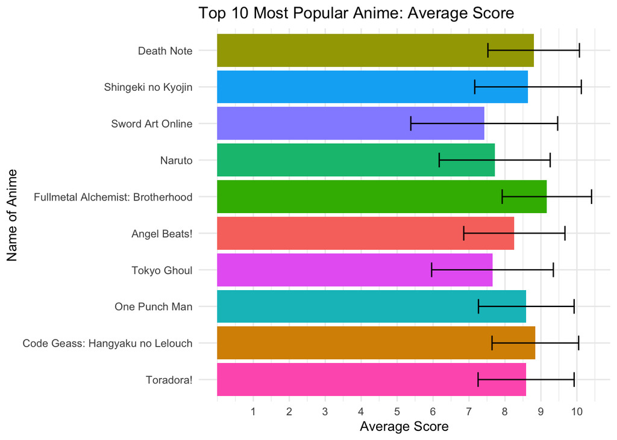

```r
library(ggplot2)
##average score for the top 10 most popular anime, ordered by popularity
##most popular at top, 10th most popular at bottom
ggplot(animetop10, aes(x=reorder(Name, +n_users), y=mean_userscore, fill=Name)) +
  geom_bar(stat = "summary", show.legend = FALSE) +
  labs(title = "Top 10 Most Popular Anime: Average Score",
       x = "Name of Anime", y = "Average Score") +
  coord_flip() +
  geom_errorbar(aes(x=Name,
                    ymin=mean_userscore-sd_userscore,
                    ymax=mean_userscore+sd_userscore),
                width = 0.4) +
  scale_y_continuous(breaks = c(1,2,3,4,5,6,7,8,9,10)) +
  theme_minimal()
```

For this graph, I wanted to visually compare the average user score across the top 10 most popular anime in the joined data set. The titles are in order of most popular (top) to 10th most popular (bottom), and the graph was flipped sideways to allow easier readability for the titles. Error bars for the average scores were added to visualize the spread of scores per title. I decided to restrict this graph to the top 10 most popular titles instead of showcasing every unique title in the data set because otherwise, the graph wouldn’t have been readable at all (there are 5,221 unique titles in total). What’s most interesting from this graph is that Sword Art Online seems to have the largest spread of scores based on its large error bar. It’s also interesting to see that despite their large popularity, the average scores for each title vary quite a bit as the range fell between 7.42 (Sword Art Online) and 9.17 (Fullmetal Alchemist: Brotherhood). If we were testing for significant difference between these scores, we could predict that no significant differences in average score between titles would be found since all the error bars overlap with each other.

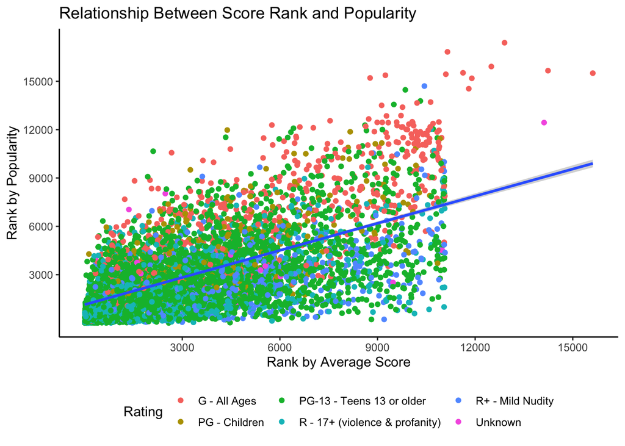

```r
#relationship between a title's score rank and popularity
animepop <- animereviews %>%
  group_by(Name) %>%
  distinct(Name, Popularity, Ranked, Rating)
ggplot(animepop, aes(x= Ranked, y=Popularity)) +
  geom_point(aes(color=Rating)) +
  geom_smooth(method="lm") +
  labs(title = "Relationship Between Score Rank and Popularity",
       x = "Rank by Average Score",
       y = "Rank by Popularity") +
  scale_y_continuous(breaks = c(3000,6000,9000,12000,15000)) +
  scale_x_continuous(breaks = c(3000,6000,9000,12000,15000)) +
  theme_classic() +
  theme(legend.position="bottom")
```

For this scatter plot, I wanted to see if a title’s global score rank (or position based on the global mean user score) correlated strongly with the title’s popularity rank (or position based on the total number of users who have that title on their list). The points were filled by the title’s maturity rating to see if the relationship changed between each category. As can be seen in the graph, it turns out there is a moderately positive relationship between score rank and popularity rank. What’s personally surprising here is that I predicted the relationship would be a bit stronger, but as it turns out, popularity doesn’t seem to be an extremely strong predictor of quality/score. Based on the maturity ratings, it’s interesting to see titles rated G stand out somewhat from the overall pattern. These titles seem to have the strongest relationship between both ranks, while titles rated PG-13 seem to have the weakest relationship. However, this may just be due to the amount of titles which fall into each category. After all, over half of titles are rated PG-13 while only 11% of titles are rated G.

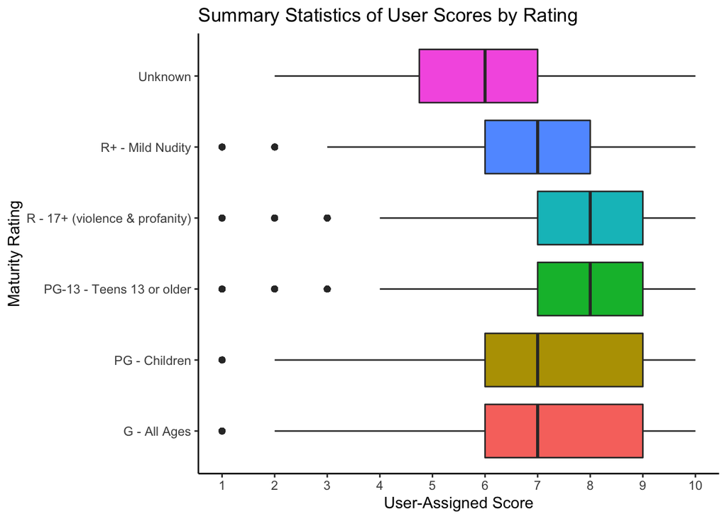

```r
##summary statistics of user scores according to a title's maturity rating
ggplot(animereviews, aes(x=Rating, y=user_score, fill=Rating)) +
  geom_boxplot(show.legend = FALSE) +
  coord_flip() +
  labs(title = "Summary Statistics of User Scores by Rating",
       y = "User-Assigned Score",
       x = "Maturity Rating") +
  scale_y_continuous(breaks = c(1,2,3,4,5,6,7,8,9,10)) +
  theme_classic()
```

For the final plot, a separate box plot of user-assigned scores was created for each maturity rating category. Excluding outliers, it was interesting to see how titles rated PG-13 and R - 17+ had the shortest range of scores. These two categories also had the largest medians and the most amount of outliers, which along with the small IQR range, may indicate a large variability overall in scores. Shows rated G and PG seem to have the most variability in the middle 50% of scores.

#### Concluding Remarks

I had a lot of fun going through these two data sets and practicing the skills I’ve learned through out class, it made me connect more with an old passion of mine. I’m already excited for the next project to come if I’ll have the same experience as this!